# INFO 201 Course Project

Benjamin Carney, Troy lu, Lance Haugen, Ayax Franco

2/26/2021

# Problem Domain

For our project, we decided to investigate the domain of social media and its impact on U.S. politics, specifically focusing on the presidency. Within this domain, we intend on analyzing former president Donald Trump’s Twitter account and all of his “tweets”. Twitter is a widely used social media platform where users can write 280-character long messages (in the form of “tweets”) for other Twitter users to read. When other Twitter users view a tweet, they have the option to “like”, reply to the tweet, or “quote-retweet” (retweeting with an added comment); all of these options count as an “interaction”, so the number of interactions that a tweet has is an indicator of how many people legitimately viewed it. The president is given an official Twitter account under the alias **@POTUS** and has the ability to adopt “followers” from the previous president’s Twitter account. When Trump became president in 2016, he took the “followers”, giving the Twitter account a large boost in interactions. Throughout his presidency, however, he still used his personal account **@realDonaldTrump**, which we will be analyzing for this project.

## Data Description

### Twitter Data

[Data Set](https://www.thetrumparchive.com)

The first six rows for `tweets_df` is shown below

| id | text | isRetweet | isDeleted | device | favorites | retweets | date | isFlagged |
| --- | --- | --- | --- | --- | --- | --- | --- | --- |
| 9.845497e+16 | Republicans and Democrats have both created our economic problems. | f | f | TweetDeck | 49 | 255 | 2011-08-02 18:07:48 | f |
| 1.234653e+18 | I was thrilled to be back in the Great city of Charlotte, North Carolina with thousands of hardworking American Patriots who love our Country, cherish our values, respect our laws, and always put AMER… | f | f | Twitter for iPhone | 73748 | 17404 | 2020-03-03 01:34:50 | f |
| 1.218011e+18 | RT @CBS_Herridge: READ: Letter to surveillance court obtained by CBS News questions where there will be further disciplinary action and cho… | t | f | Twitter for iPhone | 0 | 7396 | 2020-01-17 03:22:47 | f |
| 1.304875e+18 | The Unsolicited Mail In Ballot Scam is a major threat to our Democracy, & the Democrats know it. Almost all recent elections using this system, even though much smaller & with far fewer Ballots to cou… | f | f | Twitter for iPhone | 80527 | 23502 | 2020-09-12 20:10:58 | f |
| 1.218160e+18 | RT @MZHemingway: Very friendly telling of events here about Comey’s apparent leaking to compliant media. If you read those articles and tho… | t | f | Twitter for iPhone | 0 | 9081 | 2020-01-17 13:13:59 | f |
| 1.217963e+18 | RT @WhiteHouse: President @realDonaldTrump announced historic steps to protect the Constitutional right to pray in public schools! https://… | t | f | Twitter for iPhone | 0 | 25048 | 2020-01-17 00:11:56 | f |

### Approval Rating Data

[Data Set](https://github.com/fivethirtyeight/data/tree/master/trump-approval-ratings)

The first six rows for `approval_rating_df` is shown below

| president | subgroup | modeldate | approve_estimate | approve_hi | approve_lo | disapprove_estimate | disapprove_hi | disapprove_lo | timestamp |
| --- | --- | --- | --- | --- | --- | --- | --- | --- | --- |
| Donald Trump | Voters | 1/20/2021 | 39.40644 | 45.86536 | 32.94753 | 56.71154 | 62.46841 | 50.95466 | 11:52:51 20 Jan 2021 |
| Donald Trump | Adults | 1/20/2021 | 36.95330 | 42.81175 | 31.09486 | 59.61636 | 65.46813 | 53.76459 | 11:49:36 20 Jan 2021 |
| Donald Trump | All polls | 1/20/2021 | 38.61787 | 44.93714 | 32.29859 | 57.85297 | 63.68157 | 52.02437 | 11:47:59 20 Jan 2021 |
| Donald Trump | All polls | 1/19/2021 | 39.15823 | 45.18124 | 33.13523 | 57.43205 | 62.94107 | 51.92303 | 22:36:53 19 Jan 2021 |
| Donald Trump | Adults | 1/19/2021 | 38.05273 | 43.54456 | 32.56090 | 59.07755 | 64.48918 | 53.66592 | 22:38:31 19 Jan 2021 |
| Donald Trump | Voters | 1/19/2021 | 40.15386 | 45.82653 | 34.48119 | 55.78811 | 60.73889 | 50.83732 | 22:41:48 19 Jan 2021 |

### Lawsuit Data

[Data Set](https://github.com/fivethirtyeight/data/blob/master/trump-lawsuits/trump-lawsuits.csv)

The first six rows for `lawsuits_df` is shown below

| docketNumber | dateFiled | caseName | plaintiff | defendant | currentLocation | previousLocation | jurisdiction | judge | nature | TrumpCategory | capacity | type | issue | docketOrig | status |
| --- | --- | --- | --- | --- | --- | --- | --- | --- | --- | --- | --- | --- | --- | --- | --- |
| 2:18-cv-02217 | 2018-03-06 | Clifford v. Trump | Stephanie Clifford | Donald J. Trump; Essential Consultants LLC; Michael Cohen | District Court, Central District of California |  | 1 | S. James Otero; Frederick Mumm | 190 | 1 | 1 | 2 | 2016 Trump campaign |  | 2 |
| 3:18-cv-00484 | 2018-07-12 | Cockrum v. Donald J. Trump for President, Inc. | Roy Cockrum; Scott Comer; Eric Schoenberg | Donald J. Trump for President, Inc. | District Court, Eastern District of Virginia |  | 1 | Henry E. Hudson | 440 | 1 | 6 | 2 | 2016 Trump campaign |  | 2 |
| 1:18-cr-00602 | 2018-08-21 | United States v. Cohen | United States of America | Michael Cohen | District Court, Southern District of New York |  | 1 | William H. Pauley III | NA | 1 | 5 | 2 | 2016 Trump campaign |  | 2 |
| 18-56351 | 2018-04-30 | Clifford v. Trump | Stephanie Clifford | Donald J. Trump | 9th Circuit Court of Appeals | District Court, Central District of California | 1 | S. James Otero; Frederick Mumm | 320 | 1 | 1 | 2 | Defamation | 2:18-cv-06893 | 1 |
| 1:17-cr-00232 | 2017-11-30 | United States v. Flynn | United States of America | Michael T. Flynn | District Court, District of Columbia |  | 1 | Emmet G. Sullivan | NA | 1 | 5 | 2 | Mueller investigation |  | 1 |
| 18-3052 | 2018-08-14 | In re: Grand Jury Investigation | Andrew Miller | United States of America | D.C. Circuit Court of Appeals | District Court, District of Columbia | 1 | Karen Henderson; Judith Rogers; Sri Srinivasen; Beryl Alaine Howell | NA | 1 | 5 | 1 | Mueller investigation |  | 1 |

## Summary analysis

### Approval Rating

In our approval rating data, we have 7 columns labeled (modeldate, approve_estimate, approve_hi, approve_lo, disapprove_estimate, disapprove_hi, disapprove_lo). The dates of our data range from 2017-01-23 to 2021-01-20.

The approval rate estimate ranges from 36.40314% to 47.76497% with a mean of 41.4108917%. The highs and lows range from (41.07541% to 52.66397%) and (31.644649% to 42.86596%) respectively, with means of 46.0083586% and 36.8134248%

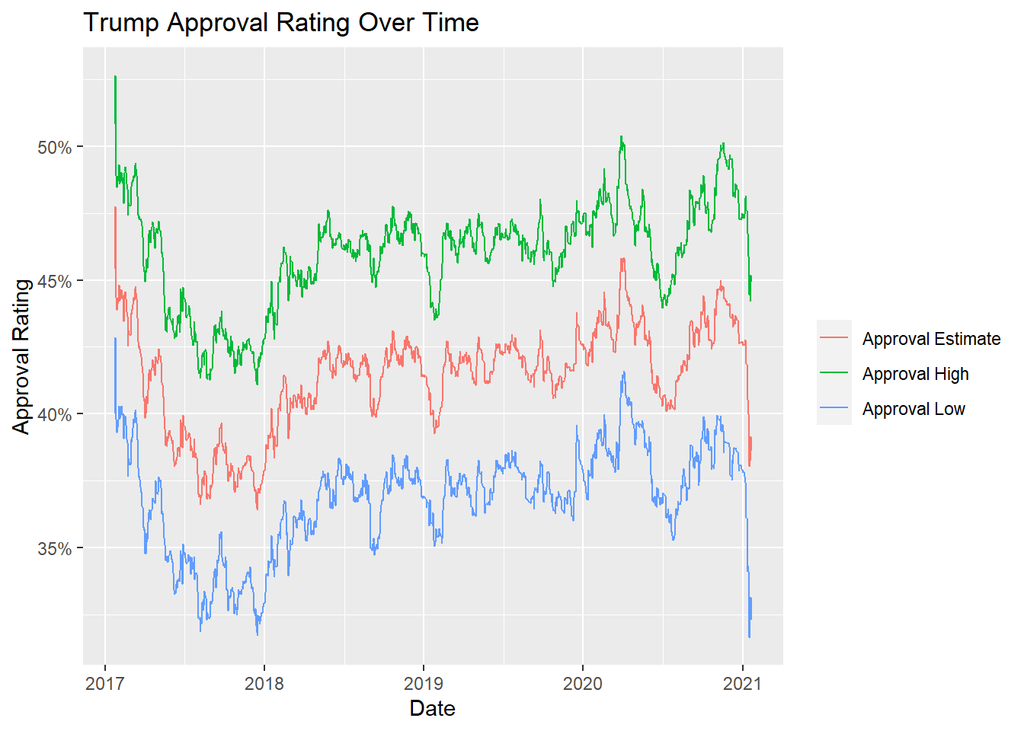

The disapproval rate estimate ranges from 41.06081% to 58.148625% with a mean of 53.4786957%. The highs and lows range from (45.61743% to 63.815783%) and (35.84175% to 52.97419%) respectively, with means of 57.8575948% and 49.0997964%.

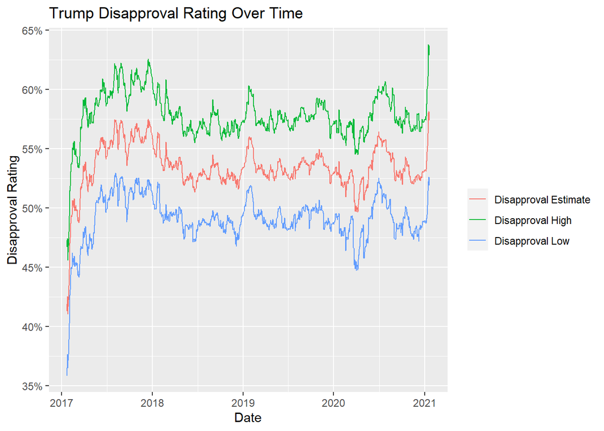

There were no outliers in this data since it is just percentages representing the American public’s view on the president at the time.

### Tweets data

In our tweets data, we have 9 columns labeled (id, text, isRetweet, isDeleted, device, favorites, retweets, date, isFlagged). The tweets dates ranged from 2009-05-04 18:54:25 to 2021-01-08 15:44:28.

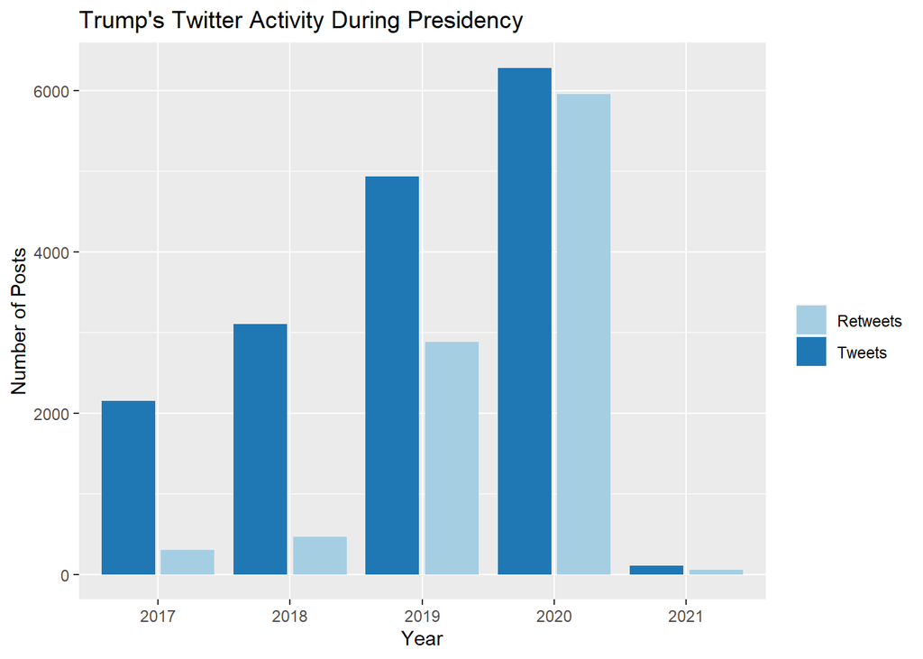

There are no outliers in this data since it is a collection of tweets posted by the president at the time.

### Lawsuit data

There are no outliers in this data since it is a collection of lawsuits Trump faced during his presidency.

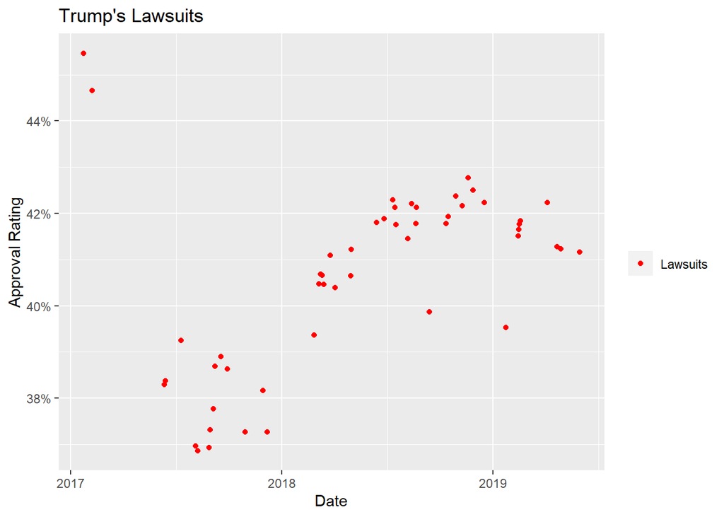

## Specific Question Analysis

### Question 1

Did Trump’s tweets affect public opinion over the course of his presidency? If so, to what extent?

The data was analyzed by taking the average favorites, retweets, and volume of tweets in a day and the average daily approval rating. After having both sets of data, they were compared to one another to see if a correlation could be established and the degree of correlation between the daily approval rating to the three other variables.

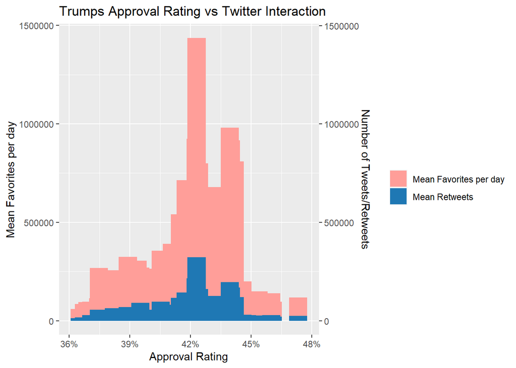

The first 6 rows for `final_df` is shown below

| date | modeldate | Mean_Approval_Estimate | n | Mean_Favourites | Mean_Retweets |
| --- | --- | --- | --- | --- | --- |
| 2017-01-24 | 1/24/2017 | 45.48088 | 4 | 106836.75 | 17718.00 |
| 2017-01-25 | 1/25/2017 | 47.32543 | 8 | 118534.62 | 24236.25 |
| 2017-01-26 | 1/26/2017 | 44.07355 | 11 | 75217.36 | 14358.27 |
| 2017-01-27 | 1/27/2017 | 43.86817 | 7 | 102844.00 | 19421.71 |
| 2017-01-28 | 1/28/2017 | 43.59434 | 5 | 79401.20 | 13564.40 |
| 2017-01-29 | 1/29/2017 | 43.77075 | 7 | 117118.00 | 25968.71 |

The sheer volume of tweets had the most correlation with the approval rating with a correlation factor of 28%. The second most impact was the amount of favorites which ended up having a correlation factor of 21.6% correlation with approval ratings. Surprisingly, retweets had the least amount of correlation only coming in with 19.3% correlation to approval rating.

In conclusion, it was established that there was some correlation between favorites, retweets, volume of tweets and Trump’s daily approval rating. The volume of tweets seemed to have the most impact on the approval rating, with favorites trailing, and retweets being the least correlated with approval rating. It is important that while the figure of approximately twenty percent may seem low it is reflective of a healthy amount of correlation. Had the correlation been high, it would have shown that his Trump’s approval rating is highly correlated with tweets and not other important factors such as policy implementations and media coverage which also influence his approval rating. If his correlation had been lower it would have shown that his tweets have minimal impact on his approval rating which would also be concerning because twitter is an outlet for Trump to voice his public opinion on current issues and a near zero correlation would indicate that the public is in almost complete disregard and indifferent to trump’s twitter usage.

### Question 2

When were Trump’s approval ratings at all time lows and at all time highs and how much was he tweeting in that time period? What major events were happening in that time period?

In this question I will be exploring the trumps approval ratings and rates at which he tweeted. Approval ratings are just what percentage of th US population approve of Tump. The rate at which Trump tweets is generally the amount he tweets in a single day.

When doing my analysis I found the top three the highs and lows for Trumps approval ratings. Then I found the number of tweets he sent out for those days, and the average of those weeks.

There is a slight correlation between the rise in tweets and a rise the approval rates in this VERY small subset, of data. Due to this being a small isolated subset it is hard to say that there is any correlation or causation with a lack of very convincing evidence. I was expecting a correlation between tweets and approval rates, and I was expecting an increase in tweets to correlate with a lower approval rate.

The first six rows for `num_tweets_on_low_approval_dates_df` is shown below

| date | approve_estimate | tweet_values | value |
| --- | --- | --- | --- |
| 2017-12-16 | 36.40314 | num_tweets | 8.000000 |
| 2017-12-16 | 36.40314 | average_past_week | 6.857143 |
| 2017-12-16 | 36.40314 | average_daily_tweets | 18.232267 |
| 2017-12-15 | 36.45856 | num_tweets | 4.000000 |
| 2017-12-15 | 36.45856 | average_past_week | 6.857143 |
| 2017-12-15 | 36.45856 | average_daily_tweets | 18.232267 |

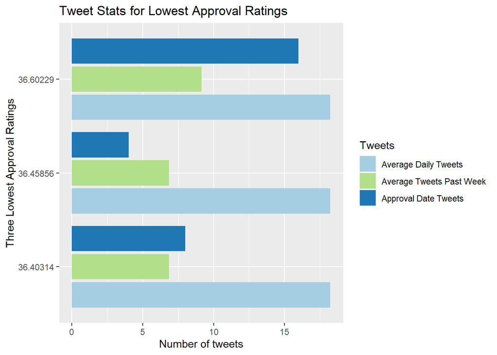

The first six rows for `num_tweets_on_high_approval_dates_df` is shown below

| date | approve_estimate | tweet_values | value |
| --- | --- | --- | --- |
| 2017-01-25 | 47.76497 | num_tweets | 8.00000 |
| 2017-01-25 | 47.76497 | average_past_week | NA |
| 2017-01-25 | 47.76497 | average_daily_tweets | 18.23227 |
| 2020-04-03 | 45.84590 | num_tweets | 15.00000 |
| 2020-04-03 | 45.84590 | average_past_week | 24.14286 |
| 2020-04-03 | 45.84590 | average_daily_tweets | 18.23227 |

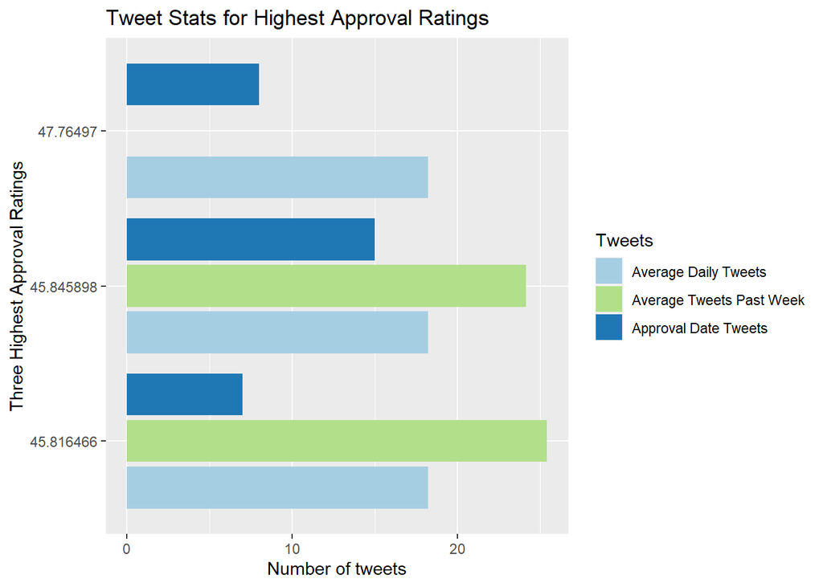

During the lowest approval rates in December of 2017 Trump was going through legal trouble and some troubling news [Regarding overdoses in the US](https://www.usnews.com/news/national-news/articles/2017-12-15/drug-overdose-deaths-continue-to-soar). The number of overdoses was by end May 2017 was 66,324, up 17% when compared to the previous 12-month period. and at this same time, [A Federal District Judge for Eastern Pennsylvania temporarily enjoins the Trump administration from implementing new rules that change the Obamacare contraceptive mandate](https://en.wikipedia.org/wiki/Portal:Current_events/December_2017). California, Delaware, Maryland, Massachusetts, New York, Virginia and Washington have also sued the federal government over the rules. In just before April 2020 a [2 trillion relief bill was approved](https://www.cbsnews.com/news/trump-signs-coronavirus-relief-package-today-2020-03-27/). ALthough tweeting more in this small subset shows a small correlation between tweeting more in the past week, and higher approval ratings, it is a more likely case that these events surrounding those dates were the cause for approval ratings and the tweets were a reaction to the current events of that time. (High tweet rates in response to good press, low tweet rates in response to bad press)

### Question 3

Did Trump’s social media usage change the approval ratings of his voters? If so, by how much and what indicators point towards the change?.

By “social media usage”, we mean to analyze the number of tweets and retweets posted by @realDonaldTrump, and we will be examining its relationship with former President Trump’s approval and disapproval ratings. For this question, we will be counting deleted tweets and retweets, since they are still purposefully posted online.

Before doing any data wrangling, we had to change the scope of the data; we would be focusing on Twitter activity and approval ratings spanning from the beginning of his presidency (January 23, 2017), to when he was suspended from Twitter (January 8, 2021). We first worked on `tweets_df`; after filtering for this time period, we then calculated for the total number of tweets and retweets in each day. One aspect to note is that Trump did not use Twitter every day, meaning there were gaps in the data. To counter this, we mutated the data to add the days where there were no tweets or retweets posted. In `approval_rating_df`, we once again filtered for the time period, and then filtered for the subgroup “All Polls”. Our group decided that rather than focusing on voters or adult, it would be best if we were to use the ratings provided by all polls. This allowed us to get the estimated approval and disapproval ratings. Finally, we joined the two estimated ratings together, compiling one approval rating dataframe, and then joined it with the tweets.

The first six rows from the data table `combined_approval_rating_df` is shown below:

| date | total_re_tweets | approve_estimate | disapprove_estimate |
| --- | --- | --- | --- |
| 2017-01-23 | 1 | 45.46693 | 41.26452 |
| 2017-01-24 | 4 | 45.44264 | 41.87849 |
| 2017-01-25 | 8 | 47.76497 | 42.52911 |
| 2017-01-26 | 11 | 44.37598 | 41.06081 |
| 2017-01-27 | 7 | 44.13586 | 41.67268 |
| 2017-01-28 | 5 | 43.87527 | 41.91362 |

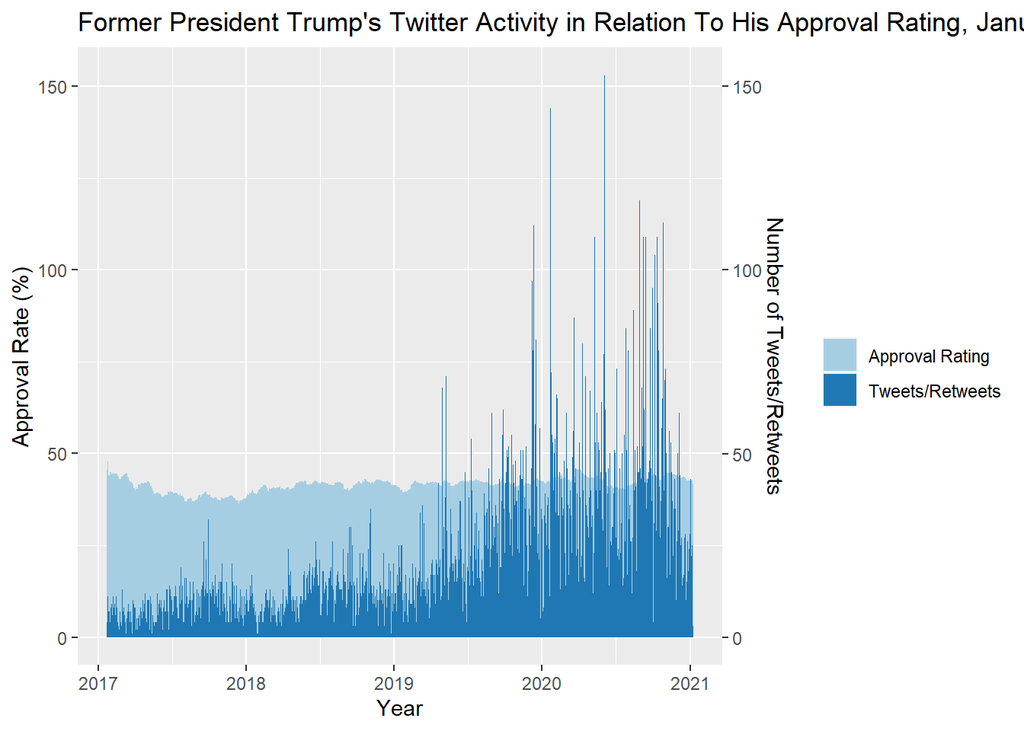

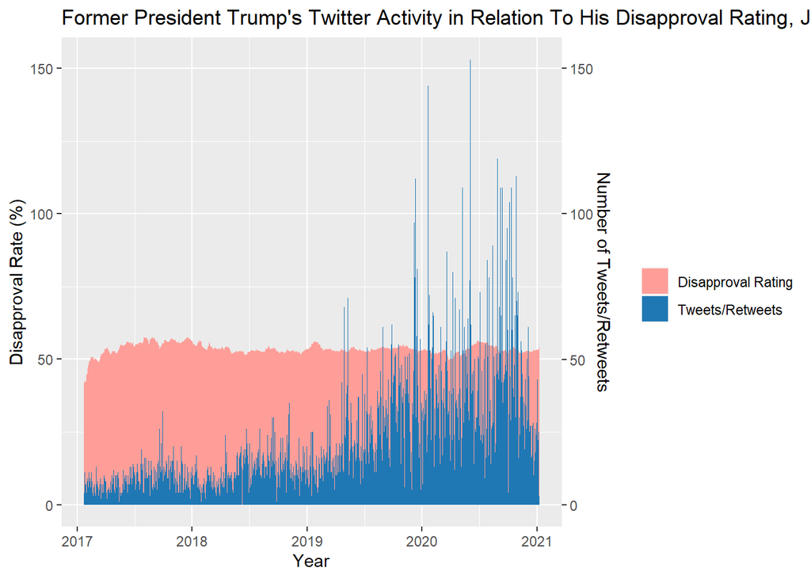

### Question 4

The question is “During his presidency, were the legal issues that Trump faced an indicator of the public perception of him? If so, to what degree?” We are looking for any correlation with President Donald Trumps legal issues and his approval rating.

Before doing any data wrangling on the approval rating data-frame, we had to change our scope of the data. We decided that to use the sub group “All groups”instead of voters and/or adults, as this would best represent the whole. Secondly, filtered the data for the start of his presidency (January 23, 2017).I first mutated the approval rating data-frame to add a column that represents the change in approval rating to the next day. (e.g. 1/1/2020 = 45.5, 1/2/2020 = 45.6, so the change of 1/1/2020 would be .1). I then joined this data-frame with the lawsuits data-frame to be bale to compare the effects of different lawsuits on the approval rating.

Through our data wrangling, we found a variety of information. The case linked with the high approval rating was “CREW v. Trump” with an approval rate of 45.46693%. The case linked with the lowest approval rating was “Doe v. Trump” with an approval rate of 36.86343%. When linked to the approval rating change the case could have caused, we found 24 positive changes, 26 negative changes, and 3 changes that had no effect.

| dateFiled | caseName | jurisdiction | capacity | type | issue | approve_estimate | approve_hi | approve_lo | disapprove_estimate | disapprove_hi | disapprove_lo | change_in_approval_of_next_day |
| --- | --- | --- | --- | --- | --- | --- | --- | --- | --- | --- | --- | --- |
| 2017-01-23 | CREW v. Trump | 1 | 1 | 2 | Emoluments | 45.46693 | 50.88971 | 40.04416 | 41.26452 | 46.68729 | 35.84175 | -0.02429 |
| 2017-02-07 | International Refugee Assistance Program v. Trump | NA | 2 | 1 | Travel ban | 44.65995 | 49.03472 | 40.28518 | 48.71205 | 53.08682 | 44.33728 | -0.15504 |
| 2017-06-12 | The District of Columbia v. Trump | 1 | 1 | 2 | Emoluments | 38.29467 | 43.10337 | 33.48596 | 55.58596 | 59.77042 | 51.40150 | -0.03933 |
| 2017-06-14 | Blumenthal v. Trump | 1 | 1 | 2 | Emoluments | 38.37910 | 43.01754 | 33.74066 | 55.65119 | 59.86611 | 51.43627 | 0.00993 |

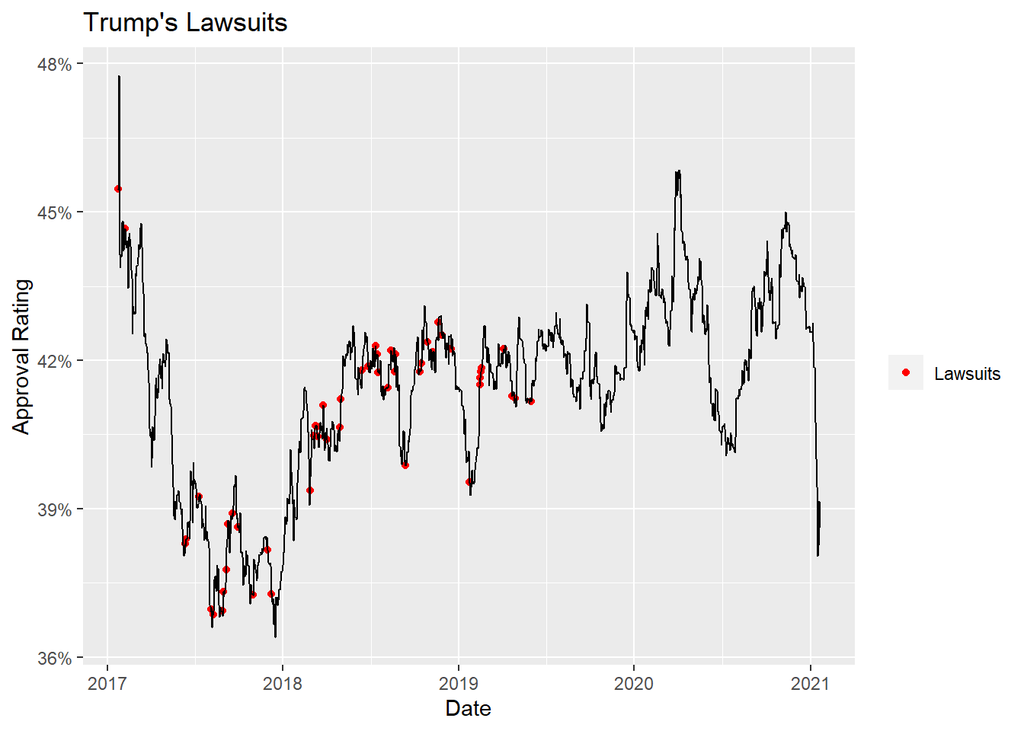

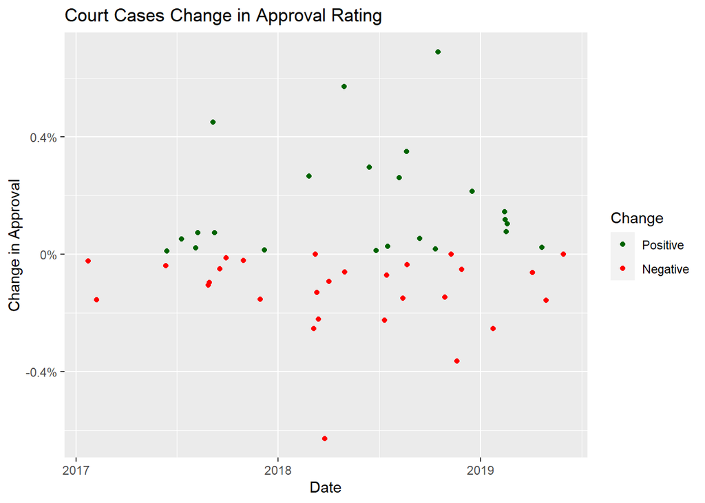

The cases with the top three positive changes were as follows:

| Case Name | Change in Approval Rating (%) |
| --- | --- |
| PEN America v. Trump | 0.69048 |
| Clifford v. Trump | 0.57166 |
| Stockman v. Trump | 0.45039 |

The cases with the top three negative changes were as follows:

| Case Name | Change in Approval Rating (%) |
| --- | --- |
| California v. Ross | -0.62866 |
| Blumenthal v. Whitaker | -0.36466 |
| Clifford v. Trump | -0.25494 |

**(NOTE: There is a possibility of the cases being labeled the same, even though they are seperate cases, just same parties involved)**

The average (absolute) change per issue was found as follows:

| Issue | Change in Approval Rating (%) | Amount of Cases |
| --- | --- | --- |
| Defamation | 0.5716600 | 1 |
| First Amendment | 0.3710400 | 2 |
| 2016 Trump campaign | 0.2768300 | 3 |
| Affordable Care Act | 0.2669900 | 1 |
| Census | 0.2403933 | 3 |
| Trump business/foundation | 0.2216750 | 2 |
| Whitaker dispute | 0.2092700 | 2 |
| Transgender military ban | 0.1840225 | 4 |
| TPS revocation | 0.1757500 | 2 |
| Travel ban | 0.1550400 | 1 |
| Asylum | 0.1353300 | 3 |
| Mueller investigation | 0.1266380 | 5 |
| National emergency declaration | 0.0955560 | 5 |
| Congressional investigation | 0.0903600 | 2 |
| Emoluments | 0.0719675 | 4 |
| DACA | 0.0515075 | 4 |
| Sanctuary cities | 0.0431333 | 6 |
| Bears Ears | 0.0140500 | 1 |
| National security tariffs | 0.0127600 | 1 |
| Sanctuary laws | 0.0000000 | 1 |

Through our analysis, we found very few court cases that could have had a major effect on Trump’s approval rating. There was no change above 0.7% within that. The greatest positive change was a 0.69048%, followed by 0.57166% and 0.45039%. The greatest negative changes were -0.62866%,-0.36466%, and -0.25494%. Since Trump’s approval rating remained relatively stagnant throughout his presidency at around low 40s, we have come to the conclusion that very few, almost none had an effect, since Trump’s approval rating was likely shifted by various other factors. We have determine that if any cases had an effect, it would likely be ones with above 0.5% change in approval rating of the next day,which concluded to be PEN America v. Trump, Clifford v. Trump, and California v. Ross. When researching these lawsuits online, we found a variety of major news articles for PEN America v. Trump,yet none for the others. We can only then assume that the only lawsuit that had a significant effect on Trump’s approval rating was PEN America v. Trump. However, this is only accounting for the court case, at the same time, there were news articles on the day the case filed about [Trump’s attack on Stephanie Clifford about her “Horseface”](https://www.nytimes.com/2018/10/16/us/politics/trump-women-insults.html). When examining the relationship between the type of cases and change in approval rating, we found that cases regarding 2016 Trump campaign and Census issues had the highest average change at 0.27683% and 0.24039333%. While these were not the highest values overall, they were the highest for issues with more than two cases, as 1-2 cases could lead to skewed results. We also found that there was almost an exact 1:1 ratio (24:26) of positive to negative changes with three at exactly 0. Overall, we can see little to no correlation with Trump’s lawsuits and his approval rating. While some cases appear to have an effect, there a variety of factors that could have played into the change and we cannot fully determine if these lawsuits had an effect.